# tony_file

Tony Daza

2023-03-16

# Innovative School Practices

## Importing the Data

Thank you Janette for compiling the data!

```r
load(here("data/canopy-schools.RData"))
```

*After looking at the data, I think we need to combine the tags into one variable as a count of number of practices if we are going to run the model as suggested*

## Counting Number of Practices

```r
main$prac_tot <- rowSums(main[c(5,6,7,8,9,10,11,12,13)], na.rm=TRUE)

main <- main %>% mutate_at(c('locale'), ~na_if(.,''))

main$locale <- as.factor(main$locale)


summary(main)
```

```
##    nces_id            school_id     school_name        school_state
##  Length:566         Min.   :  1.0   Length:566         Length:566
##  Class :character   1st Qu.: 98.0   Class :character   Class :character
##  Mode  :character   Median :206.0   Mode  :character   Mode  :character
##                     Mean   :238.9
##                     3rd Qu.:360.0
##                     Max.   :633.0
##
##   prac_culture    prac_sel_assess prac_community    prac_mental
##  Min.   :0.0000   Min.   :0.000   Min.   :0.0000   Min.   :0.0000
##  1st Qu.:0.0000   1st Qu.:0.000   1st Qu.:0.0000   1st Qu.:0.0000
##  Median :1.0000   Median :1.000   Median :1.0000   Median :1.0000
##  Mean   :0.6131   Mean   :0.629   Mean   :0.5919   Mean   :0.6625
##  3rd Qu.:1.0000   3rd Qu.:1.000   3rd Qu.:1.0000   3rd Qu.:1.0000
##  Max.   :1.0000   Max.   :1.000   Max.   :1.0000   Max.   :1.0000
##
##  prac_restorative prac_marginalized prac_sel_curriculum prac_sel_integrated
##  Min.   :0.0000   Min.   :0.0000    Min.   :0.0000      Min.   :0.0000
##  1st Qu.:0.0000   1st Qu.:0.0000    1st Qu.:0.0000      1st Qu.:0.0000
##  Median :1.0000   Median :1.0000    Median :0.0000      Median :1.0000
##  Mean   :0.6449   Mean   :0.6042    Mean   :0.3516      Mean   :0.6519
##  3rd Qu.:1.0000   3rd Qu.:1.0000    3rd Qu.:1.0000      3rd Qu.:1.0000
##  Max.   :1.0000   Max.   :1.0000    Max.   :1.0000      Max.   :1.0000
##
##  prac_resources       locale     frpl_percent    bipoc_percent
##  Min.   :0.000   Rural   :129   Min.   :  0.00   Min.   :  0.00
##  1st Qu.:0.000   Suburban:105   1st Qu.: 25.93   1st Qu.: 22.34
##  Median :0.000   Urban   :326   Median : 50.00   Median : 54.44
##  Mean   :0.447   NA's    :  6   Mean   : 50.82   Mean   : 54.50
##  3rd Qu.:1.000                  3rd Qu.: 77.08   3rd Qu.: 89.64
##  Max.   :1.000                  Max.   :100.00   Max.   :100.00
##                                 NA's   :117      NA's   :91
##       year           wave          prac_tot
##  Min.   :2019   Min.   :0.000   Min.   :0.000
##  1st Qu.:2019   1st Qu.:0.000   1st Qu.:3.000
##  Median :2021   Median :2.000   Median :5.000
##  Mean   :2021   Mean   :1.673   Mean   :5.196
##  3rd Qu.:2022   3rd Qu.:3.000   3rd Qu.:7.000
##  Max.   :2022   Max.   :3.000   Max.   :9.000
##
```

```r
# Looks like we have 6 NA value schools now for Locale.
## 91 NA values for bipoc.
## 117 NA values for frpl.
```

```r
# 2016 Political Data.
library(readxl)


pres_16 <- import("~/Desktop/prez_election_16.csv")
```

```r
library(datasets)

region <- as.data.frame(state.region)
region <- region %>% dplyr::mutate(State_ID = row_number())


states <- as.data.frame(state.name)
states <- states %>% dplyr::mutate(State_ID = row_number())

subregion <- as.data.frame(state.division)
subregion <- subregion %>% dplyr::mutate(State_ID = row_number())

# I realized that this data set doesn't have the District of Columbia
# It leads to some NA values
# I will sort them out later and for now just filter them out

abbr <- as.data.frame(state.abb)
abbr <- abbr %>% dplyr::mutate(State_ID = row_number())

regions <- dplyr::full_join(states, subregion, by = "State_ID")
regions <- dplyr::full_join(regions, abbr, by = "State_ID")
regions <- dplyr::full_join(regions, region, by = "State_ID")
regions$state.division[[8]] <- "Middle Atlantic"
regions$state.region[[8]] <- "Northeast"
# For some reason Delaware was listed as the South and that seemed wrong.
regions$state.division[[32]] <- "New England"


# New row for DC
DC <- data.frame(state.name = "District of Columbia",
                 State_ID = 51,
                 state.division = "Middle Atlantic",
                 state.region = "Northeast",
                 state.abb = "DC")

# Adding in DC
regions <- rbind(regions, DC)
```

**Adding State Info to politics**

```r
library(dplyr)
pres_16 <- pres_16 %>% dplyr::rename(state.abb = STATE)
pres_16 <- dplyr::full_join(pres_16, regions, by = "state.abb")
pres_16 <- pres_16 %>% select(-c("State_ID", "state.abb", "All Other Parties"))
pres_16 <- pres_16 %>% dplyr::rename(school_state = state.name)
pres_16 <- pres_16 %>% dplyr::rename(school_region = state.region)
pres_16 <- pres_16 %>% dplyr::rename(school_subregion = state.division)

pres_16 <- pres_16 %>% mutate(pct_dem = round(((`Democrat Popular`/`Total Vote`)*100),2))



# Determine quantile thresholds for splitting categories
quantiles <- quantile(pres_16$pct_dem, probs = c(0, 1/3, 2/3, 1))

# Creating a new variable indicating the political affiliation based on percent voting democrat
pres_16 <- pres_16 %>%
  mutate(Political_Affiliation = case_when(
    pct_dem >= quantiles[3] ~ "Democrat",
    pct_dem >= quantiles[2] ~ "Neutral",
    TRUE ~ "Conservative"
  ))

# But does that show the same thing as electoral college?

pres_16 <- pres_16 %>%
  mutate(`Republican Electoral` = replace(`Republican Electoral`, is.na(`Republican Electoral`), 0),
         `Democrat Electoral` = replace(`Democrat Electoral`, is.na(`Democrat Electoral`), 0))
# Hawaii splits electoral votes
pres_16$`Democrat Electoral`[[12]] <- 3
# Washington splits electoral votes
pres_16$`Democrat Electoral`[[48]] <- 8
# Texas splits electoral votes
pres_16$`Republican Electoral`[[44]] <- 36

pres_16 <- pres_16 %>%
  dplyr::mutate(`Republican Electoral` = as.numeric(`Republican Electoral`),
        `Democrat Electoral` =  as.numeric(`Democrat Electoral`))

# Now we can add the electoral votes
# Will need to fix Hawaii, Washington, and Texas
pres_16 <- pres_16 %>%
  group_by(school_state) %>%
  dplyr::mutate(Electoral_Total = `Republican Electoral` + `Democrat Electoral`)

# Hawaii has 4 electoral votes
pres_16$Electoral_Total[[12]] <- 4
# Washington has 12 electoral votes
pres_16$Electoral_Total[[48]] <- 12
# Texas has 38 electoral votes
pres_16$Electoral_Total[[44]] <- 38

# Now we will determine if the state's electoral votes went primarily to Republicans or democrats
pres_16 <- pres_16 %>% mutate(electoral_pct_dem = round(((`Democrat Electoral`/Electoral_Total)*100),2))

# Now a new category of state party by electoral college.
pres_16 <- pres_16 %>% mutate(Political_Aff_2 = case_when(
    electoral_pct_dem >= 50 ~ "Democrat",
    TRUE ~ "Conservative"
  ))

state_party <- pres_16 %>% select(c("school_state", "Political_Affiliation", "Political_Aff_2"))
```

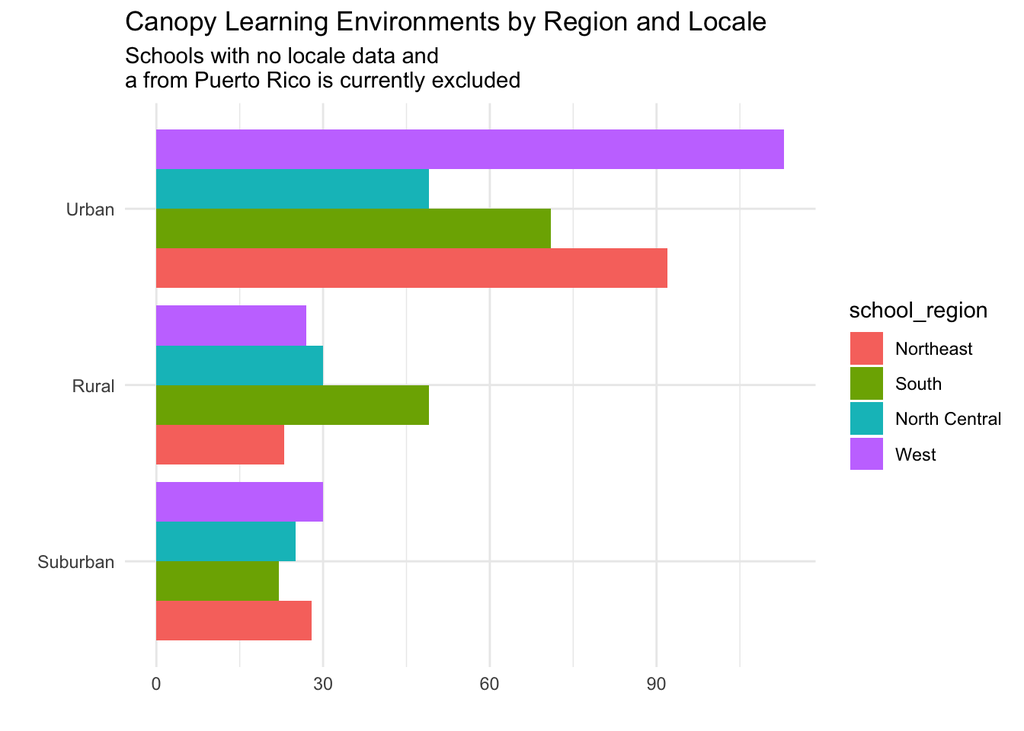

```r
main$school_state[[54]] <- "New York"
main$school_state[[136]] <- "California"
main$school_state[[373]] <- "South Carolina"
main$school_state[[377]] <- "Washington"


regions <- regions %>% select(-"State_ID")
regions <- regions %>% dplyr::rename(school_state = state.name)
regions <- regions %>% dplyr::rename(school_region = state.region)
regions <- regions %>% dplyr::rename(school_subregion = state.division)


full_region <- left_join(main, regions, by = "school_state")

full_region <- left_join(full_region, state_party, by = "school_state")

full_region %>%
  filter(school_state != "Puerto Rico") %>%
  filter(locale != "") %>%
  dplyr::group_by(school_region, locale) %>%
  dplyr::summarize(counts = n()) %>%
  ggplot(aes(x = reorder(locale, counts), y = counts, fill = school_region)) +
  geom_col(position = "dodge") +
  theme(axis.text.x = element_text(angle = 45, hjust = 1)) +
  coord_flip() +
  theme_minimal() +
  labs(title = "Canopy Learning Environments by Region and Locale",
       subtitle = "Schools with no locale data and \na from Puerto Rico is currently excluded",
       x = "",
       y = "")
```

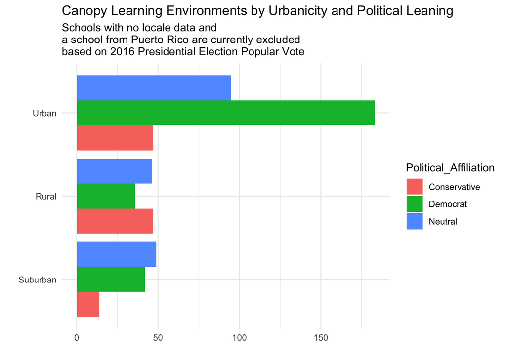

```r
full_region %>%
  filter(school_state != "Puerto Rico") %>%
  filter(locale != "") %>%
  dplyr::group_by(Political_Affiliation, locale) %>%
  dplyr::summarize(counts = n()) %>%
  ggplot(aes(x = reorder(locale, counts), y = counts, fill = Political_Affiliation)) +
  geom_col(position = "dodge") +
  theme(axis.text.x = element_text(angle = 45, hjust = 1)) +
  coord_flip() +
  theme_minimal() +
  labs(title = "Canopy Learning Environments by Urbanicity and Political Leaning",
       subtitle = "Schools with no locale data and \na school from Puerto Rico are currently excluded \nbased on 2016 Presidential Election Popular Vote",
       x = "",
       y = "")
```

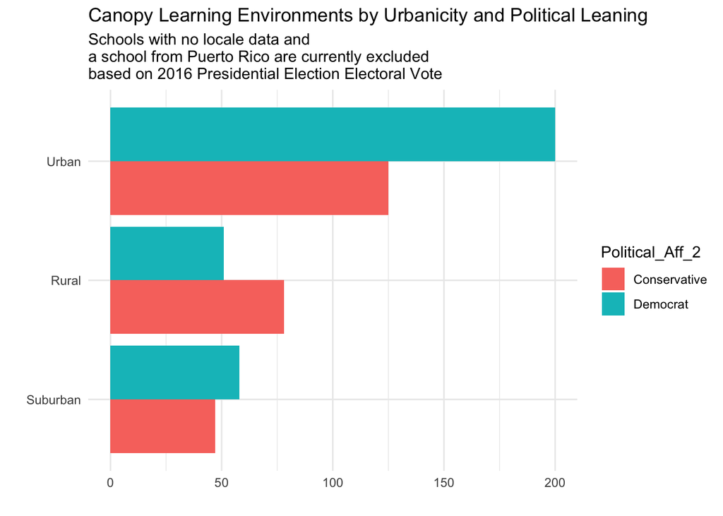

```r
full_region %>%
  filter(school_state != "Puerto Rico") %>%
  filter(locale != "") %>%
  dplyr::group_by(Political_Aff_2, locale) %>%
  dplyr::summarize(counts = n()) %>%
  ggplot(aes(x = reorder(locale, counts), y = counts, fill = Political_Aff_2)) +
  geom_col(position = "dodge") +
  theme(axis.text.x = element_text(angle = 45, hjust = 1)) +
  coord_flip() +
  theme_minimal() +
  labs(title = "Canopy Learning Environments by Urbanicity and Political Leaning",
       subtitle = "Schools with no locale data and \na school from Puerto Rico are currently excluded \nbased on 2016 Presidential Election Electoral Vote",
       x = "",
       y = "")
```

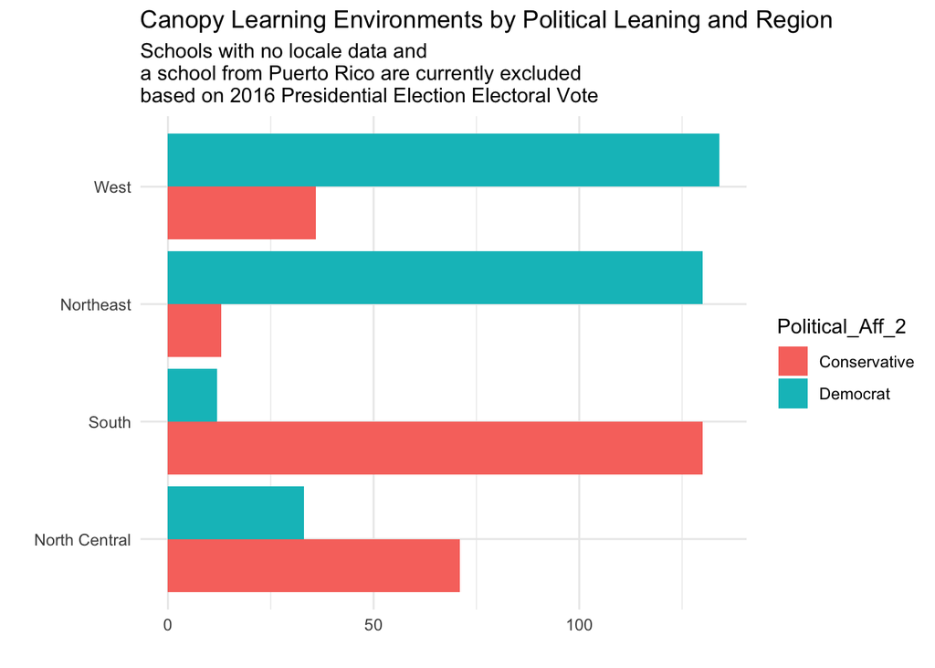

```r
full_region %>%
  filter(school_state != "Puerto Rico") %>%
  filter(locale != "") %>%
  dplyr::group_by(Political_Aff_2, school_region) %>%
  dplyr::summarize(counts = n()) %>%
  ggplot(aes(x = reorder(school_region, counts), y = counts, fill = Political_Aff_2)) +
  geom_col(position = "dodge") +
  theme(axis.text.x = element_text(angle = 45, hjust = 1)) +
  coord_flip() +
  theme_minimal() +
  labs(title = "Canopy Learning Environments by Political Leaning and Region",
       subtitle = "Schools with no locale data and \na school from Puerto Rico are currently excluded \nbased on 2016 Presidential Election Electoral Vote",
       x = "",
       y = "")
```

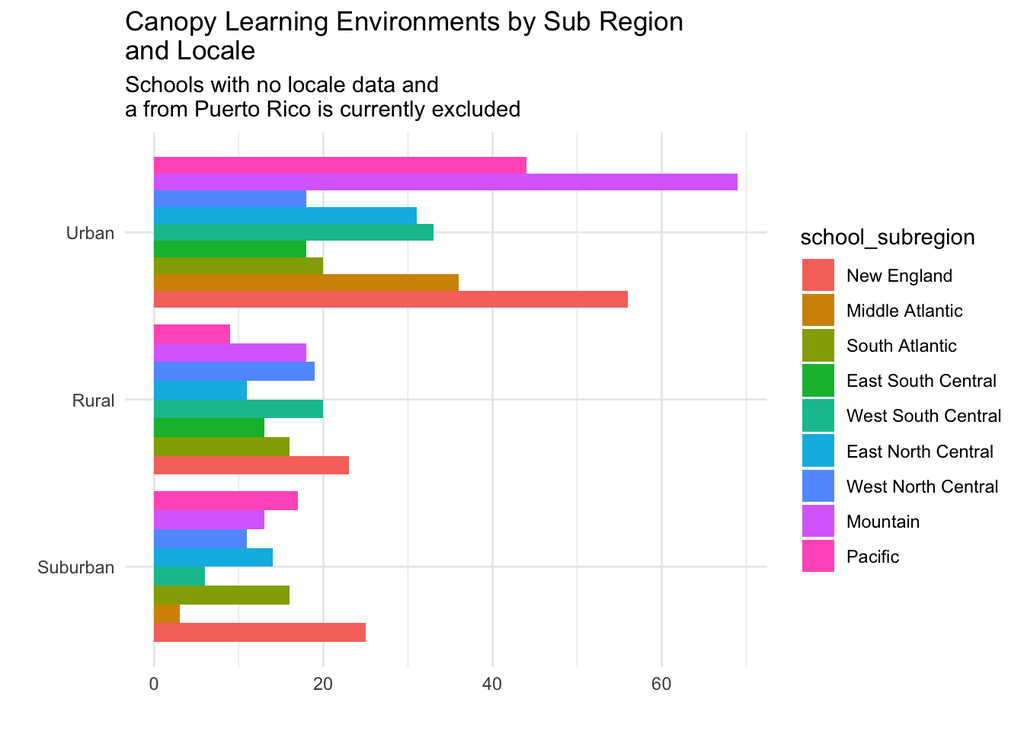

```r
full_region %>%
  filter(school_state != "Puerto Rico") %>%
  filter(locale != "") %>%
  dplyr::group_by(school_subregion, locale) %>%
  dplyr::summarize(counts = n()) %>%
  ggplot(aes(x = reorder(locale, counts), y = counts, fill = school_subregion)) +
  geom_col(position = "dodge") +
  theme(axis.text.x = element_text(angle = 45, hjust = 1)) +
  coord_flip() +
  theme_minimal() +
  labs(title = "Canopy Learning Environments by Sub Region \nand Locale",
       subtitle = "Schools with no locale data and \na from Puerto Rico is currently excluded",
       x = "",
       y = "")
```

## Examining data to model

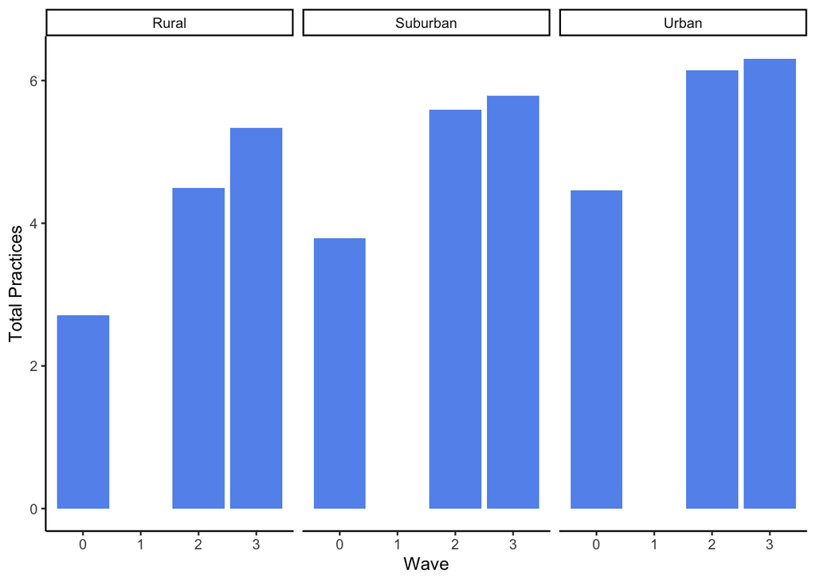

```r
main %>%
  filter(locale != "NA") %>%
  group_by(locale) %>%
ggplot(aes(x = wave, y = prac_tot )) +
  geom_bar(stat = "summary", fun = "mean", fill="cornflowerblue") +
  facet_grid(~locale) +
  theme_classic()+
  labs(y = "Total Practices", x = "Wave")
```

### Descriptive Table

```r
datatable(round(describe(main[5:19], fast = TRUE, ranges = FALSE), digits = 2))
```

|  | vars | n | mean | sd | se |
| --- | --- | --- | --- | --- | --- |
| prac_culture | 1 | 566 | 0.61 | 0.49 | 0.02 |
| prac_sel_assess | 2 | 566 | 0.63 | 0.48 | 0.02 |
| prac_community | 3 | 566 | 0.59 | 0.49 | 0.02 |
| prac_mental | 4 | 566 | 0.66 | 0.47 | 0.02 |
| prac_restorative | 5 | 566 | 0.64 | 0.48 | 0.02 |
| prac_marginalized | 6 | 566 | 0.6 | 0.49 | 0.02 |
| prac_sel_curriculum | 7 | 566 | 0.35 | 0.48 | 0.02 |
| prac_sel_integrated | 8 | 566 | 0.65 | 0.48 | 0.02 |
| prac_resources | 9 | 566 | 0.45 | 0.5 | 0.02 |
| locale | 10 | 560 |  |  |  |

[output cut: 5 more lines]

### Distribution:

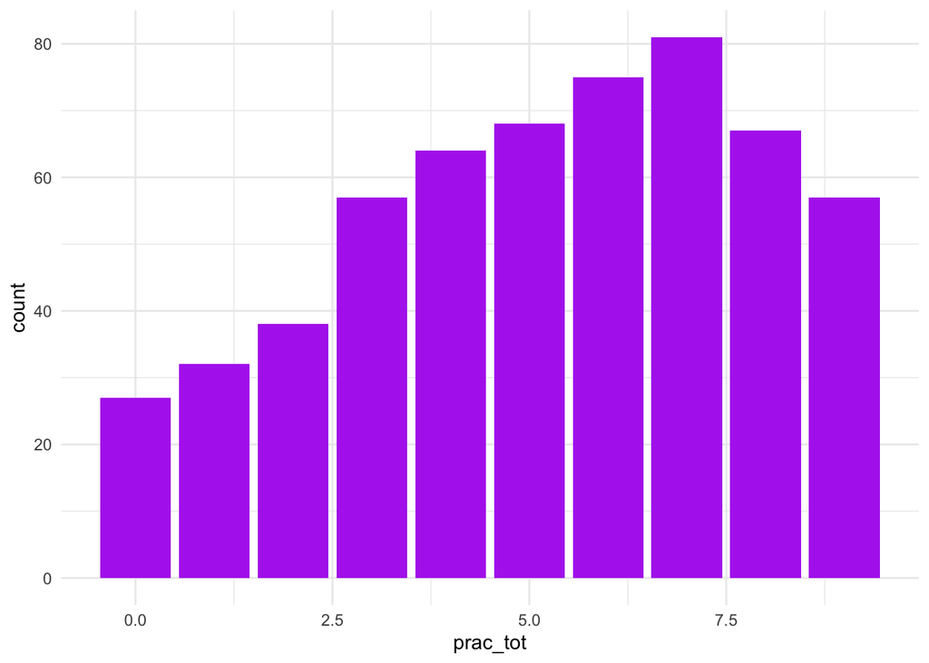

```r
main %>%
  ggplot(aes(x = prac_tot)) +
  geom_bar(fill= "darkorchid2") +
  theme_minimal()
```

## Missing Data

Here we are running an MCAR test to examing to see if the missing data for locale, free and reduced price lunch, and percent bipoc is missing at random. If it is at random then we will continue as planned. If not, we will use imputed data.

```r
main$cbipoc_percent <- c(scale(main$bipoc_percent,  center=TRUE, scale=TRUE))
main$cfrpl_percent <- c(scale(main$frpl_percent,  center=TRUE, scale=TRUE))

main_mcar <- main %>%
  select(wave, frpl_percent, locale, bipoc_percent, prac_tot)

main_mcar$locale <- as.numeric(main_mcar$locale)

mcar_test(main_mcar)
```

```
## # A tibble: 1 × 4
##   statistic    df p.value missing.patterns
##       <dbl> <dbl>   <dbl>            <int>
## 1      36.2    17 0.00429                6
```

There is a difference between complete cases and partial cases. Code complete and partial data and run t tests to try to predict difference between cases. If there is a mean difference, we should add that as a control in the model.

Attrition analysis: examine schools that participated over all 3 waves Examine means test of the two groups and report that.

**Only impute data if missing completely at random**

In this case though, because we know the reason for why it is missing might make sense.

### Examining mean differences

```r
## Setting up the groups(Complete and incomplete data to examine mean differences)
main_complete <- main %>%
  filter(bipoc_percent != "NA" & frpl_percent != "NA" & locale != "NA")%>%
  mutate(group = 1) # schools with complete data are coded 1

main_miss <- main %>%
  filter(is.na(bipoc_percent) | is.na(frpl_percent) | is.na(locale))%>%
  mutate(group=0) # schools with missing data are coded 0

main_test <- full_join(main_complete, main_miss) # rejoining the data
```

[output not shown]

```r
main_test$group <- as.factor(main_test$group)

## Testing the mean difference in total practices for complete and incomplete school data
t.test(prac_tot ~ group, data = main_test)
```

```
##
##  Welch Two Sample t-test
##
## data:  prac_tot by group
## t = 0.89152, df = 208.32, p-value = 0.3737
## alternative hypothesis: true difference in means between group 0 and group 1 is not equal to 0
## 95 percent confidence interval:
##  -0.2712194  0.7190372
## sample estimates:
## mean in group 0 mean in group 1
##        5.370968        5.147059
```

```r
# This suggests that the difference in practice total is not significant between school groups.

# To double check because our data is not exactly normal, here is the wilcox test
wilcox.test(prac_tot ~ group, data = main_test)
```

```
##
##  Wilcoxon rank sum test with continuity correction
##
## data:  prac_tot by group
## W = 28466, p-value = 0.507
## alternative hypothesis: true location shift is not equal to 0
```

```r
# Is in agreement with Welch's test that the difference in practice totals is not significant

## Examining the locale data for missing and complete school data
locale_count_complete <- main_test %>% filter(group == 1) %>% dplyr::count(locale)
locale_count_complete$prct_locale <- round((locale_count_complete$n/442)*100,digits = 2)
datatable(locale_count_complete) # Percent of each locale for complete schools data
```

|  | locale | n | prct_locale |
| --- | --- | --- | --- |
| 1 | Rural | 112 | 25.34 |
| 2 | Suburban | 84 | 19 |
| 3 | Urban | 246 | 55.66 |

```r
locale_count_miss <- main_test %>% filter(group == 0) %>% dplyr::count(locale)
locale_count_miss$prct_locale <- round((locale_count_miss$n/124)*100, digits = 2)
datatable(locale_count_miss) # percent of each locale for incomplete schools data
```

|  | locale | n | prct_locale |
| --- | --- | --- | --- |
| 1 | Rural | 17 | 13.71 |
| 2 | Suburban | 21 | 16.94 |
| 3 | Urban | 80 | 64.52 |
| 4 |  | 6 | 4.84 |

```r
main_test$locale <- as.numeric(main_test$locale) # need to change locale to a factor to examine the difference here.

t.test(locale ~ group, data = main_test)
```

```
##
##  Welch Two Sample t-test
##
## data:  locale by group
## t = 2.9261, df = 207.8, p-value = 0.003814
## alternative hypothesis: true difference in means between group 0 and group 1 is not equal to 0
## 95 percent confidence interval:
##  0.07527584 0.38618593
## sample estimates:
## mean in group 0 mean in group 1
##        2.533898        2.303167
```

```r
# Suggests that the difference in location is significant by locale between the complete and incomplete data

wilcox.test(locale ~ group, data = main_test)
```

```
##
##  Wilcoxon rank sum test with continuity correction
##
## data:  locale by group
## W = 29706, p-value = 0.008695
## alternative hypothesis: true location shift is not equal to 0
```

```r
# It does seem like the groups differ by percent of locale missing.
```

Based on an examination of the mean differences between groups of complete data schools and missing data schools, it seems like there is no difference in the mean total practices of schools with missing frpl and bipoc data compared to schools with complete data.

When examining the location data, there is a difference between complete data schools and missing data schools with regard to location data. Complete data schools had a higher percentage of rural schools (25% to 14% in the missing data group) as well as a higher percentage of suburban schools (19% to 17%). Alternatively, the missing data group had a higher percentage of urban schools (65% compared to 56% of Urban schools in the complete data group).

## Fixed Effects

This is how he did assignment 3 where we first examined if practices changed overtime in general without any predictors.

```r
GLMMCond <- glmer(prac_tot ~ 1 + wave + (1|school_id),
                  family = poisson,
                  data = main)
summary(GLMMCond)
```

```
## Generalized linear mixed model fit by maximum likelihood (Laplace
##   Approximation) [glmerMod]
##  Family: poisson  ( log )
## Formula: prac_tot ~ 1 + wave + (1 | school_id)
##    Data: main
##
##      AIC      BIC   logLik deviance df.resid
##   2628.3   2641.3  -1311.1   2622.3      563
##
## Scaled residuals:
##     Min      1Q  Median      3Q     Max
## -2.0788 -0.5678  0.1061  0.5265  1.7615
##
## Random effects:
##  Groups    Name        Variance Std.Dev.
##  school_id (Intercept) 0.07601  0.2757
## Number of obs: 566, groups:  school_id, 378
##
## Fixed effects:
##             Estimate Std. Error z value Pr(>|z|)
## (Intercept)  1.31751    0.04228  31.165   <2e-16 ***
## wave         0.15816    0.01800   8.786   <2e-16 ***
## ---
## Signif. codes:  0 '***' 0.001 '**' 0.01 '*' 0.05 '.' 0.1 ' ' 1
##
## Correlation of Fixed Effects:
##      (Intr)
## wave -0.800
```

```r
tab_model(GLMMCond)
```

|  | prac tot |  |  |
| --- | --- | --- | --- |
| Predictors | Incidence Rate Ratios | CI | p |
| (Intercept) | 3.73 | 3.44 – 4.06 | **<0.001** |
| wave | 1.17 | 1.13 – 1.21 | **<0.001** |
| Random Effects |  |  |  |
| σ<sup>2</sup> | 0.19 |  |  |
| τ<sub>00</sub> <sub>school_id</sub> | 0.08 |  |  |
| ICC | 0.29 |  |  |
| N <sub>school_id</sub> | 378 |  |  |
| Observations | 566 |  |  |
| Marginal R<sup>2</sup> / Conditional R<sup>2</sup> | 0.118 / 0.375 |  |  |

**ICC: 0.29**

Total observations 566 (Before we have missing data in the predictors)

In this case, wave does seem to be significant.

## Model with predictors

Here we are adding in locale, percent bipoc, and percent frpl as predictors in our model.

```r
GLMMfix <- glmer(prac_tot ~ 1 + wave + locale + cbipoc_percent + cfrpl_percent + (1|school_id),
                  family = poisson,
                  data = main)

## No interaction term here
summary(GLMMfix)
```

```
## Generalized linear mixed model fit by maximum likelihood (Laplace
##   Approximation) [glmerMod]
##  Family: poisson  ( log )
## Formula: prac_tot ~ 1 + wave + locale + cbipoc_percent + cfrpl_percent +
##     (1 | school_id)
##    Data: main
##
##      AIC      BIC   logLik deviance df.resid
##   2048.8   2077.4  -1017.4   2034.8      435
##
## Scaled residuals:
##      Min       1Q   Median       3Q      Max
## -2.26478 -0.60731  0.09857  0.61054  2.15865
##
## Random effects:
##  Groups    Name        Variance Std.Dev.
##  school_id (Intercept) 0.04942  0.2223
## Number of obs: 442, groups:  school_id, 321
##
## Fixed effects:
##                Estimate Std. Error z value Pr(>|z|)
## (Intercept)     1.12958    0.06918  16.329  < 2e-16 ***
## wave            0.15401    0.01956   7.872 3.48e-15 ***
## localeSuburban  0.21797    0.08183   2.664 0.007727 **
## localeUrban     0.26239    0.07629   3.439 0.000584 ***
## cbipoc_percent  0.03131    0.03761   0.833 0.405044
## cfrpl_percent   0.04790    0.03187   1.503 0.132931
## ---
## Signif. codes:  0 '***' 0.001 '**' 0.01 '*' 0.05 '.' 0.1 ' ' 1
##
## Correlation of Fixed Effects:
##             (Intr) wave   lclSbr lclUrb cbpc_p
## wave        -0.466
## localeSbrbn -0.586 -0.042
## localeUrban -0.715 -0.119  0.586
## cbipc_prcnt  0.339  0.127 -0.234 -0.574
## cfrpl_prcnt -0.213 -0.124  0.266  0.327 -0.610
```

```r
tab_model(GLMMfix)
```

|  | prac tot |  |  |
| --- | --- | --- | --- |
| Predictors | Incidence Rate Ratios | CI | p |
| (Intercept) | 3.09 | 2.70 – 3.54 | **<0.001** |
| wave | 1.17 | 1.12 – 1.21 | **<0.001** |
| locale [Suburban] | 1.24 | 1.06 – 1.46 | **0.008** |
| locale [Urban] | 1.30 | 1.12 – 1.51 | **0.001** |
| cbipoc percent | 1.03 | 0.96 – 1.11 | 0.405 |
| cfrpl percent | 1.05 | 0.99 – 1.12 | 0.133 |
| Random Effects |  |  |  |
| σ<sup>2</sup> | 0.19 |  |  |
| τ<sub>00</sub> <sub>school_id</sub> | 0.05 |  |  |
| ICC | 0.21 |  |  |
| N <sub>school_id</sub> | 321 |  |  |
| Observations | 442 |  |  |
| Marginal R<sup>2</sup> / Conditional R<sup>2</sup> | 0.206 / 0.374 |  |  |

### Model check Conditional

Is this any better than the unconditional model?

```r
AIC(GLMMCond,GLMMfix)
```

```
##          df      AIC
## GLMMCond  3 2628.282
## GLMMfix   7 2048.808
```

```r
BIC(GLMMCond,GLMMfix)
```

```
##          df      BIC
## GLMMCond  3 2641.297
## GLMMfix   7 2077.448
```

```r
# Cannot test comparison because different proportion of missing data between the models.
# test_lrt(GLMMCond,GLMMfix)
```

The model with predictors is better than the conditional model according to the AIC and BIC.

## Model Interactions

**Locale x Wave**

The previous model did not have an interaction effect. In this model we have the interaction between wave and locale but not of percent bipoc and percent frpl.

```r
GLMMfix1 <- glmer(prac_tot ~ 1 + wave +
                    locale +
                    cbipoc_percent +
                    cfrpl_percent +
                    locale*wave +
                    (1|school_id),
                  family = poisson,
                  data = main)
summary(GLMMfix1)
```

```
## Generalized linear mixed model fit by maximum likelihood (Laplace
##   Approximation) [glmerMod]
##  Family: poisson  ( log )
## Formula: prac_tot ~ 1 + wave + locale + cbipoc_percent + cfrpl_percent +
##     locale * wave + (1 | school_id)
##    Data: main
##
##      AIC      BIC   logLik deviance df.resid
##   2046.9   2083.7  -1014.4   2028.9      433
##
## Scaled residuals:
##     Min      1Q  Median      3Q     Max
## -2.2565 -0.6652  0.1165  0.5996  2.7312
##
## Random effects:
##  Groups    Name        Variance Std.Dev.
##  school_id (Intercept) 0.04626  0.2151
## Number of obs: 442, groups:  school_id, 321
##
## Fixed effects:
##                     Estimate Std. Error z value Pr(>|z|)
## (Intercept)          0.96368    0.10061   9.578  < 2e-16 ***
## wave                 0.24708    0.04404   5.611 2.01e-08 ***
## localeSuburban       0.40069    0.13961   2.870   0.0041 **
## localeUrban          0.48403    0.12035   4.022 5.78e-05 ***
## cbipoc_percent       0.03684    0.03753   0.981   0.3264
## cfrpl_percent        0.04969    0.03159   1.573   0.1157
## wave:localeSuburban -0.09947    0.06201  -1.604   0.1087
## wave:localeUrban    -0.12216    0.05035  -2.426   0.0153 *
## ---
## Signif. codes:  0 '***' 0.001 '**' 0.01 '*' 0.05 '.' 0.1 ' ' 1
##
## Correlation of Fixed Effects:
##             (Intr) wave   lclSbr lclUrb cbpc_p cfrpl_ wv:lcS
## wave        -0.795
## localeSbrbn -0.703  0.586
## localeUrban -0.855  0.642  0.597
## cbipc_prcnt  0.180  0.123 -0.054 -0.321
## cfrpl_prcnt -0.156 -0.042  0.142  0.225 -0.606
## wv:lclSbrbn  0.560 -0.712 -0.813 -0.453 -0.101  0.016
## wav:lclUrbn  0.703 -0.870 -0.522 -0.776 -0.057 -0.025  0.621
## optimizer (Nelder_Mead) convergence code: 0 (OK)
## Model failed to converge with max|grad| = 0.00422755 (tol = 0.002, component 1)
```

```r
tab_model(GLMMfix1)
```

|  | prac tot |  |  |
| --- | --- | --- | --- |
| Predictors | Incidence Rate Ratios | CI | p |
| (Intercept) | 2.62 | 2.15 – 3.19 | **<0.001** |
| wave | 1.28 | 1.17 – 1.40 | **<0.001** |
| locale [Suburban] | 1.49 | 1.14 – 1.96 | **0.004** |
| locale [Urban] | 1.62 | 1.28 – 2.05 | **<0.001** |
| cbipoc percent | 1.04 | 0.96 – 1.12 | 0.326 |
| cfrpl percent | 1.05 | 0.99 – 1.12 | 0.116 |
| wave × locale [Suburban] | 0.91 | 0.80 – 1.02 | 0.109 |
| wave × locale [Urban] | 0.89 | 0.80 – 0.98 | **0.015** |
| Random Effects |  |  |  |
| σ<sup>2</sup> | 0.19 |  |  |
| τ<sub>00</sub> <sub>school_id</sub> | 0.05 |  |  |
| ICC | 0.20 |  |  |
| N <sub>school_id</sub> | 321 |  |  |
| Observations | 442 |  |  |
| Marginal R<sup>2</sup> / Conditional R<sup>2</sup> | 0.235 / 0.388 |  |  |

**ICC: 0.20**

**Marginal R^2: 0.235 (23.5% of variance explained)**

**Conditional R^2: 0.388 (38.8% of variance explained)**

In this model it seems like the interaction between wave and urban location was significant but not for suburban and wave.

### Model check Interaction

Is this any better than the model without the interaction term?

```r
AIC(GLMMfix,GLMMfix1)
```

```
##          df      AIC
## GLMMfix   7 2048.808
## GLMMfix1  9 2046.864
```

```r
BIC(GLMMfix,GLMMfix1)
```

```
##          df      BIC
## GLMMfix   7 2077.448
## GLMMfix1  9 2083.686
```

```r
test_lrt(GLMMfix,GLMMfix1)
```

```
## # Likelihood-Ratio-Test (LRT) for Model Comparison (ML-estimator)
##
## Name     |    Model | df | df_diff | Chi2 |     p
## -------------------------------------------------
## GLMMfix  | glmerMod |  7 |         |      |
## GLMMfix1 | glmerMod |  9 |       2 | 5.94 | 0.051
```

## Predictors of growth

Here we add a model with interaction effects between not only locale but percent bipoc and percent frpl as well.

```r
GLMMfix2 <- glmer(prac_tot ~ 1 + wave +
                    locale +
                    cbipoc_percent +
                    cfrpl_percent +
                    locale*wave +
                    cbipoc_percent*wave +
                    cfrpl_percent*wave +
                    (1|school_id),
                  family = poisson,
                  data = main)
summary(GLMMfix2)
```

```
## Generalized linear mixed model fit by maximum likelihood (Laplace
##   Approximation) [glmerMod]
##  Family: poisson  ( log )
## Formula: prac_tot ~ 1 + wave + locale + cbipoc_percent + cfrpl_percent +
##     locale * wave + cbipoc_percent * wave + cfrpl_percent * wave +
##     (1 | school_id)
##    Data: main
##
##      AIC      BIC   logLik deviance df.resid
##   2050.2   2095.2  -1014.1   2028.2      431
##
## Scaled residuals:
##     Min      1Q  Median      3Q     Max
## -2.2423 -0.6547  0.1205  0.6052  2.7075
##
## Random effects:
##  Groups    Name        Variance Std.Dev.
##  school_id (Intercept) 0.04586  0.2141
## Number of obs: 442, groups:  school_id, 321
##
## Fixed effects:
##                     Estimate Std. Error z value Pr(>|z|)
## (Intercept)          0.98278    0.10380   9.468  < 2e-16 ***
## wave                 0.23522    0.04718   4.985 6.19e-07 ***
## localeSuburban       0.38287    0.14220   2.692 0.007093 **
## localeUrban          0.44719    0.13203   3.387 0.000706 ***
## cbipoc_percent       0.06991    0.06406   1.091 0.275147
## cfrpl_percent        0.02014    0.05118   0.394 0.693863
## wave:localeSuburban -0.08788    0.06389  -1.375 0.169004
## wave:localeUrban    -0.10253    0.05867  -1.747 0.080568 .
## wave:cbipoc_percent -0.01765    0.02748  -0.642 0.520779
## wave:cfrpl_percent   0.01653    0.02268   0.729 0.466114
## ---
## Signif. codes:  0 '***' 0.001 '**' 0.01 '*' 0.05 '.' 0.1 ' ' 1
##
## Correlation of Fixed Effects:
##             (Intr) wave   lclSbr lclUrb cbpc_p cfrpl_ wv:lcS wv:lcU wv:cb_
## wave        -0.808
## localeSbrbn -0.697  0.572
## localeUrban -0.856  0.692  0.572
## cbipc_prcnt  0.296 -0.218 -0.088 -0.503
## cfrpl_prcnt -0.241  0.169  0.235  0.342 -0.570
## wv:lclSbrbn  0.575 -0.709 -0.819 -0.472  0.063 -0.181
## wav:lclUrbn  0.711 -0.879 -0.482 -0.818  0.388 -0.260  0.600
## wv:cbpc_prc -0.244  0.355  0.074  0.410 -0.811  0.444 -0.152 -0.514
## wv:cfrpl_pr  0.188 -0.245 -0.191 -0.269  0.438 -0.789  0.242  0.307 -0.552
## optimizer (Nelder_Mead) convergence code: 0 (OK)
## Model failed to converge with max|grad| = 0.0559967 (tol = 0.002, component 1)
```

```r
## Model failed to converge with optimizer. Can check afix package for optimizers later.
```

### Model check Interactions

**Interaction: Wave X Locale , Wave X Percent FRPL , Wave X Percent BIPOC**

```r
AIC(GLMMfix1,GLMMfix2)
```

```
##          df      AIC
## GLMMfix1  9 2046.864
## GLMMfix2 11 2050.231
```

```r
BIC(GLMMfix1,GLMMfix2)
```

```
##          df      BIC
## GLMMfix1  9 2083.686
## GLMMfix2 11 2095.236
```

```r
test_lrt(GLMMfix1,GLMMfix2)
```

```
## # Likelihood-Ratio-Test (LRT) for Model Comparison (ML-estimator)
##
## Name     |    Model | df | df_diff | Chi2 |     p
## -------------------------------------------------
## GLMMfix1 | glmerMod |  9 |         |      |
## GLMMfix2 | glmerMod | 11 |       2 | 0.63 | 0.729
```

The second model does not seem to be better which would make sense given that we likely wouldn’t expect percent frpl and percent bipoc to change significantly in a short timeframe and adding the interactions of those two with wave increased our degrees of freedom.

# Plots

**Not using a model**

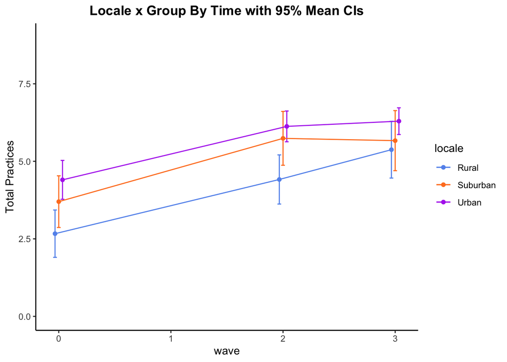

```r
localegg <- summarySE(na.omit(main), measurevar="prac_tot", groupvars=c("locale","wave"))

localegg$wave<-as.numeric(localegg$wave)

# The errorbars overlapped, so use position_dodge to move them horizontally
pd <- position_dodge(0.1) # move them .05 to the left and right

# Use 95% confidence interval instead of SEM

ggplot(localegg, aes(x=wave, y=prac_tot, color=locale)) +
  geom_errorbar(aes(ymin=prac_tot-ci, ymax=prac_tot+ci), width=.1, position=pd) +
  ylab("Total Practices") +
  ylim(0,9) +
  geom_line(position=pd) +
  geom_point(position=pd) + theme_classic() +
  scale_color_manual(values=c("cornflowerblue", "chocolate1", "darkorchid2")) +
  ggtitle("Locale x Group By Time with 95% Mean CIs") +
  theme(plot.title = element_text(hjust = 0.5, lineheight=.8, face="bold"))
```

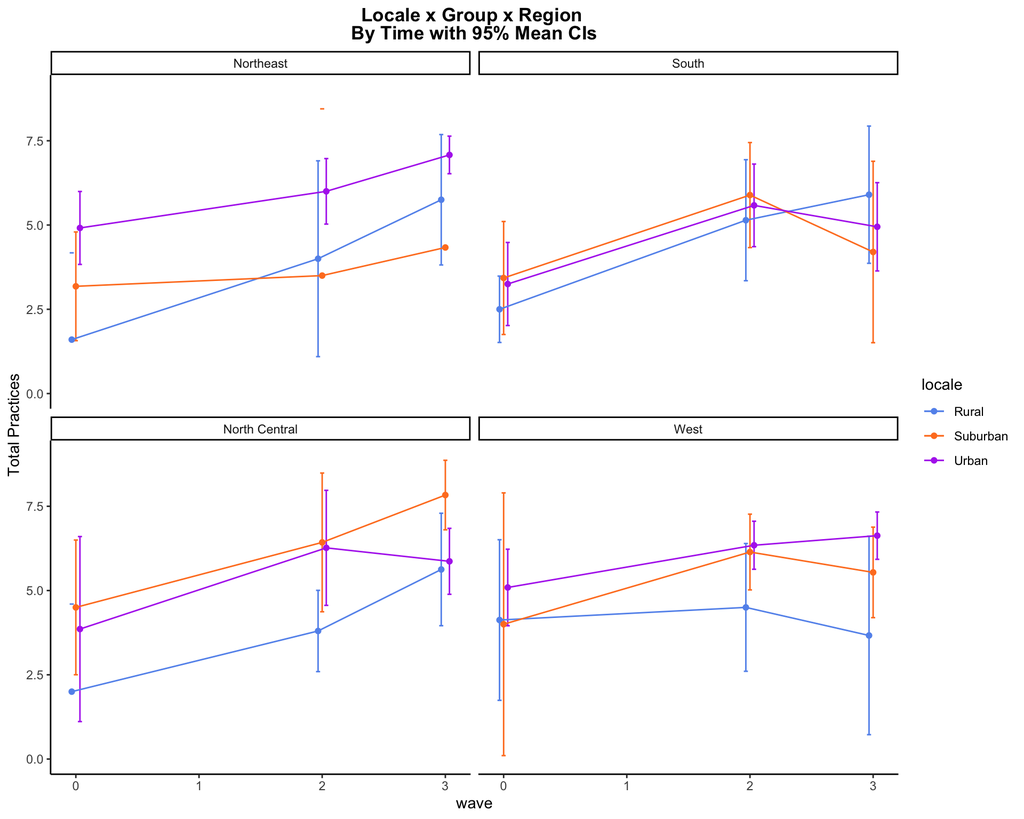

```r
localegg2 <- summarySE(na.omit(full_region), measurevar="prac_tot", groupvars=c("locale","wave", "school_region"))

localegg2$wave<-as.numeric(localegg2$wave)

# Use 95% confidence interval instead of SEM

ggplot(localegg2, aes(x=wave, y=prac_tot, color=locale)) +
  geom_errorbar(aes(ymin=prac_tot-ci, ymax=prac_tot+ci), width=.1, position=pd) +
  ylab("Total Practices") +
  ylim(0,9) +
  facet_wrap(~school_region) +
  geom_line(position=pd) +
  geom_point(position=pd) + theme_classic() +
  scale_color_manual(values=c("cornflowerblue", "chocolate1", "darkorchid2")) +
  ggtitle("Locale x Group x Region \nBy Time with 95% Mean CIs") +
  theme(plot.title = element_text(hjust = 0.5, lineheight=.8, face="bold"))
```

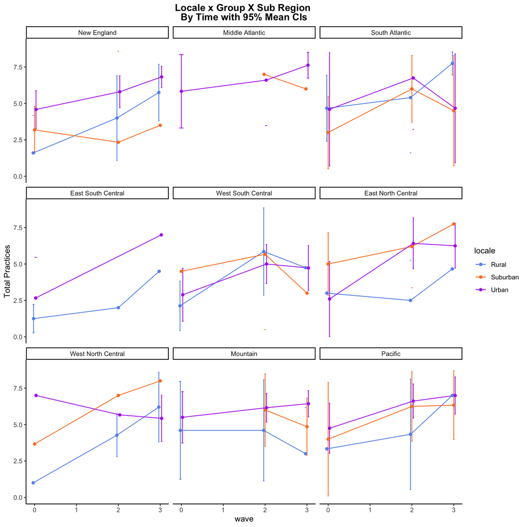

```r
localegg3 <- summarySE(na.omit(full_region), measurevar="prac_tot", groupvars=c("locale","wave", "school_subregion"))

localegg3$wave<-as.numeric(localegg3$wave)

# Use 95% confidence interval instead of SEM

ggplot(localegg3, aes(x=wave, y=prac_tot, color=locale)) +
  geom_errorbar(aes(ymin=prac_tot-ci, ymax=prac_tot+ci), width=.1, position=pd) +
  ylab("Total Practices") +
  ylim(0,9) +
  facet_wrap(~school_subregion) +
  geom_line(position=pd) +
  geom_point(position=pd) + theme_classic() +
  scale_color_manual(values=c("cornflowerblue", "chocolate1", "darkorchid2")) +
  ggtitle("Locale x Group X Sub Region \nBy Time with 95% Mean CIs") +
  theme(plot.title = element_text(hjust = 0.5, lineheight=.8, face="bold"))
```

## No Interaction Model

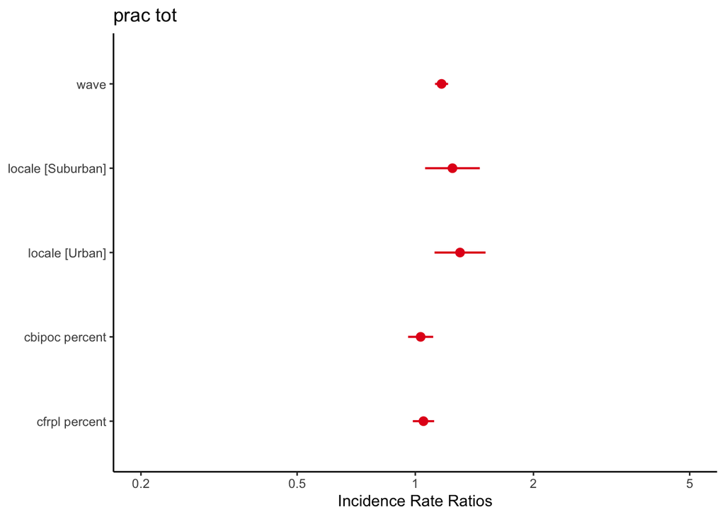

```r
plot_model(GLMMfix) + theme_classic ()
```

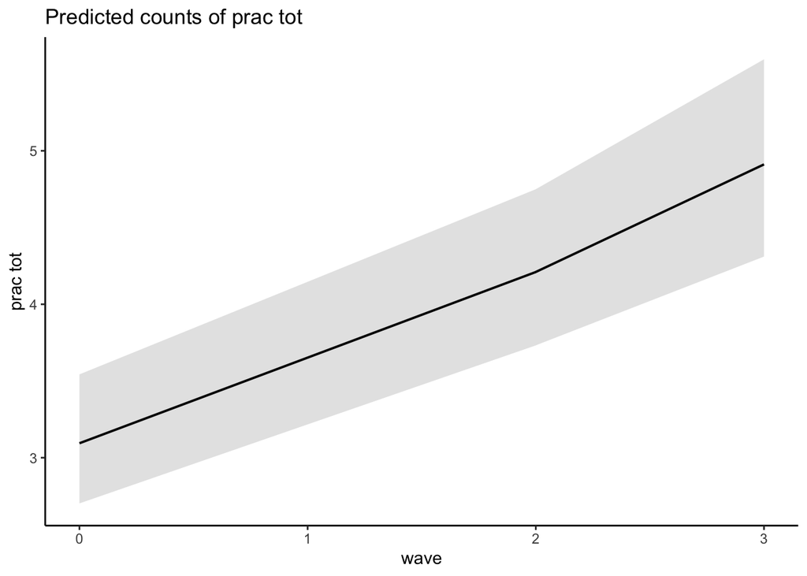

```r
plot_model(GLMMfix,type = "eff")$wave + theme_classic () # plot the effect of Time (Wave)
```

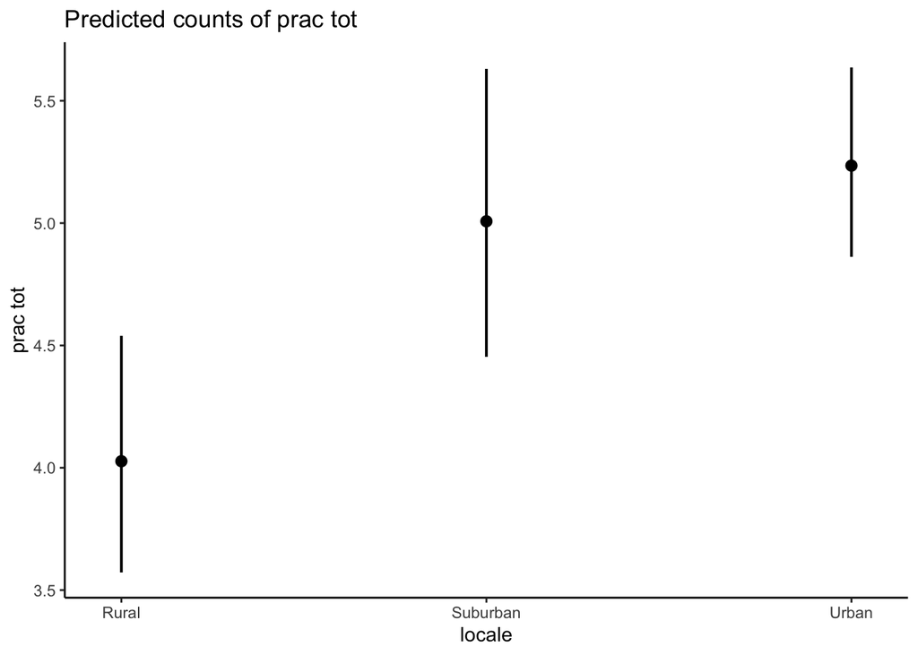

```r
plot_model(GLMMfix,type = "eff")$locale + theme_classic () # plot the effect of locale
```

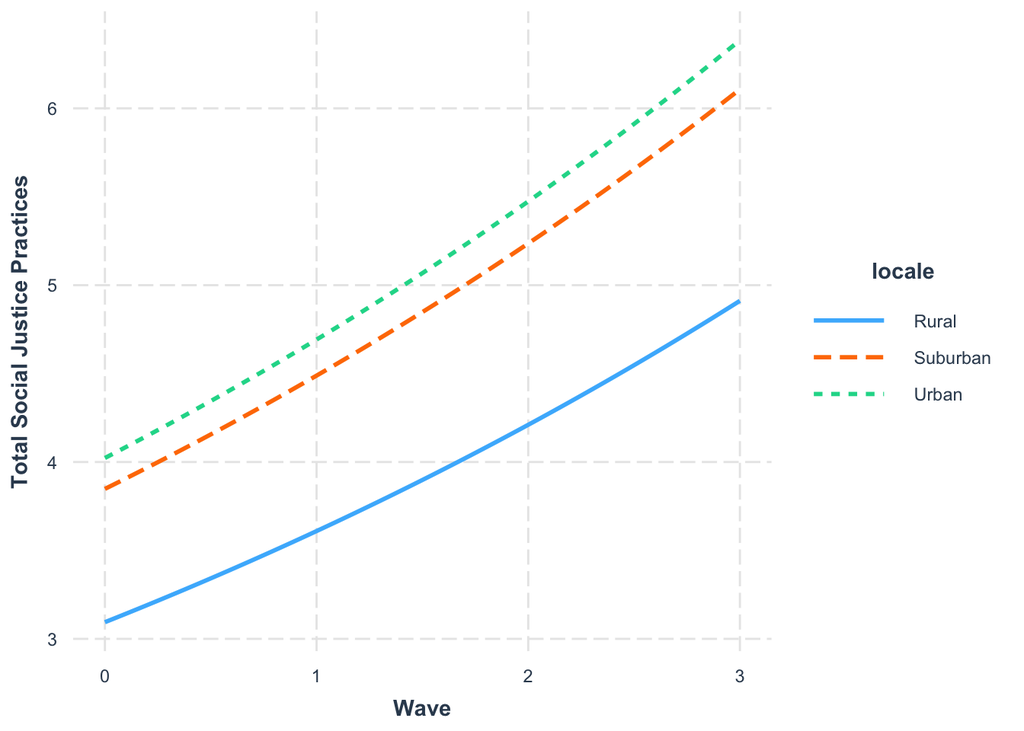

```r
interact_plot(model=GLMMfix, pred = wave, modx = locale)+
  labs(x = "Wave", y = "Total Social Justice Practices") # Enter the predictor of growth in the final model
```

## Interaction Model

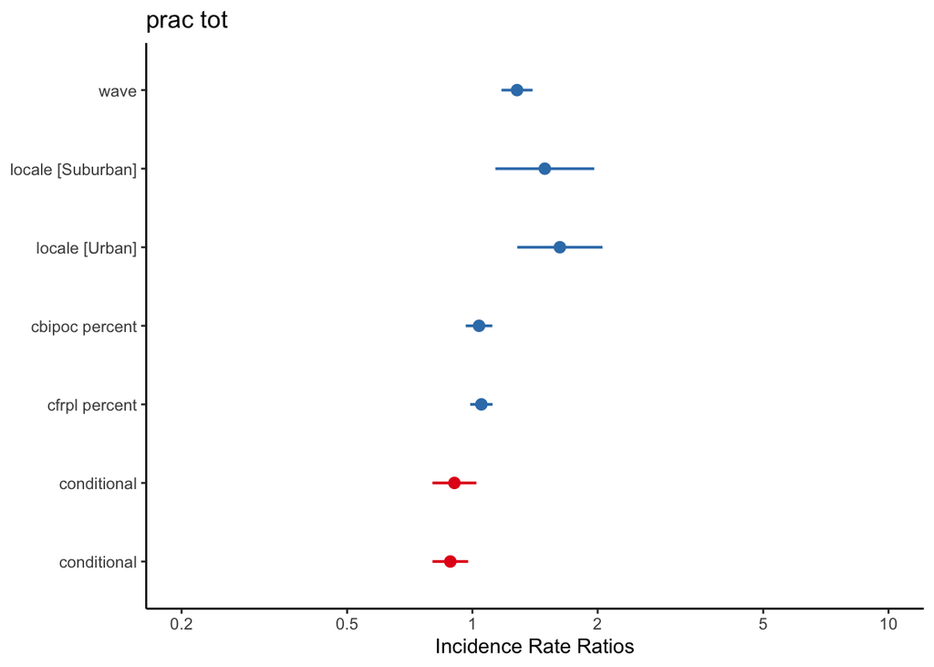

```r
plot_model(GLMMfix1) + theme_classic ()
```

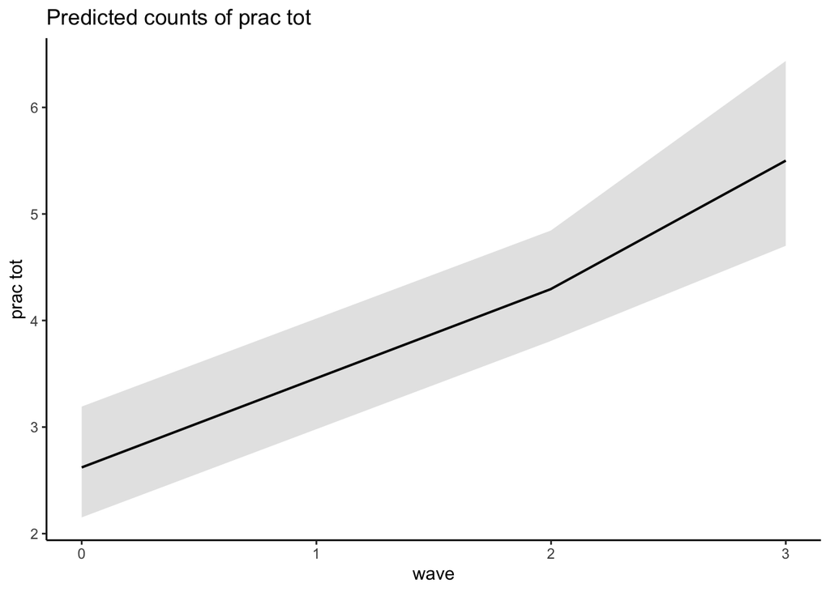

```r
plot_model(GLMMfix1,type = "eff")$wave + theme_classic () # plot the effect of Time (Wave)
```

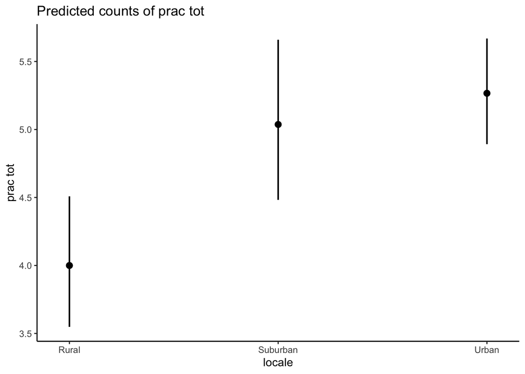

```r
plot_model(GLMMfix1,type = "eff")$locale + theme_classic () # plot the effect of locale
```

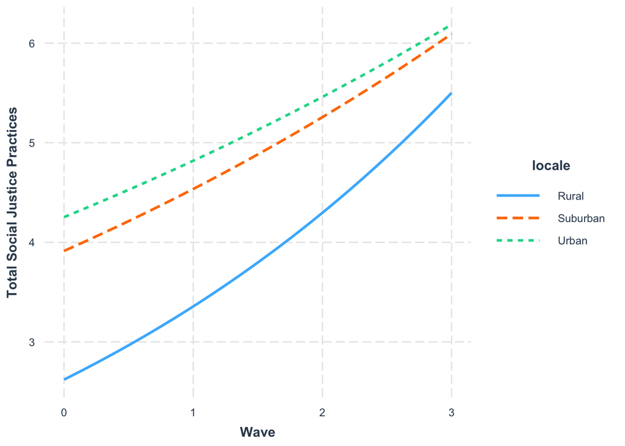

```r
interact_plot(model=GLMMfix1, pred = wave, modx = locale) +
  labs(x = "Wave", y = "Total Social Justice Practices")
```

```r
# Enter the predictor of growth in the final model
```

# Tab Models

## No interaction Model

**Using the Predictor model with no interaction term** Rated as the best model based on test of fit and BIC.

```r
tab_model(GLMMfix)
```

|  | prac tot |  |  |
| --- | --- | --- | --- |
| Predictors | Incidence Rate Ratios | CI | p |
| (Intercept) | 3.09 | 2.70 – 3.54 | **<0.001** |
| wave | 1.17 | 1.12 – 1.21 | **<0.001** |
| locale [Suburban] | 1.24 | 1.06 – 1.46 | **0.008** |
| locale [Urban] | 1.30 | 1.12 – 1.51 | **0.001** |
| cbipoc percent | 1.03 | 0.96 – 1.11 | 0.405 |
| cfrpl percent | 1.05 | 0.99 – 1.12 | 0.133 |
| Random Effects |  |  |  |
| σ<sup>2</sup> | 0.19 |  |  |
| τ<sub>00</sub> <sub>school_id</sub> | 0.05 |  |  |
| ICC | 0.21 |  |  |
| N <sub>school_id</sub> | 321 |  |  |
| Observations | 442 |  |  |
| Marginal R<sup>2</sup> / Conditional R<sup>2</sup> | 0.206 / 0.374 |  |  |

## Interaction Model

**Using the Predictor model with an interaction term between Locale X Wave** Better according to AIC

```r
tab_model(GLMMfix1)
```

|  | prac tot |  |  |
| --- | --- | --- | --- |
| Predictors | Incidence Rate Ratios | CI | p |
| (Intercept) | 2.62 | 2.15 – 3.19 | **<0.001** |
| wave | 1.28 | 1.17 – 1.40 | **<0.001** |
| locale [Suburban] | 1.49 | 1.14 – 1.96 | **0.004** |
| locale [Urban] | 1.62 | 1.28 – 2.05 | **<0.001** |
| cbipoc percent | 1.04 | 0.96 – 1.12 | 0.326 |
| cfrpl percent | 1.05 | 0.99 – 1.12 | 0.116 |
| wave × locale [Suburban] | 0.91 | 0.80 – 1.02 | 0.109 |
| wave × locale [Urban] | 0.89 | 0.80 – 0.98 | **0.015** |
| Random Effects |  |  |  |
| σ<sup>2</sup> | 0.19 |  |  |
| τ<sub>00</sub> <sub>school_id</sub> | 0.05 |  |  |
| ICC | 0.20 |  |  |
| N <sub>school_id</sub> | 321 |  |  |
| Observations | 442 |  |  |
| Marginal R<sup>2</sup> / Conditional R<sup>2</sup> | 0.235 / 0.388 |  |  |

# Imputed Data

If needed, here is the model with imputed data, if the MCAR test determines that the missing data is not at random.

## Missing data

**Examines the missing data in the main dataset**

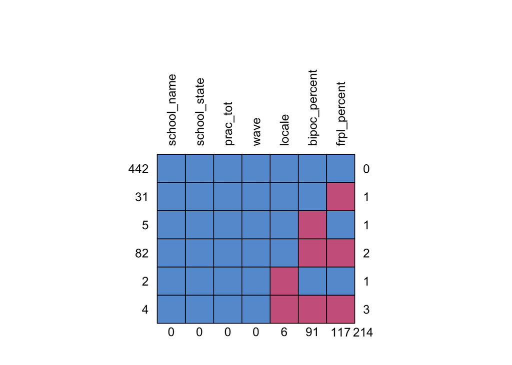

```
##     school_name school_state prac_tot wave locale bipoc_percent frpl_percent
## 442           1            1        1    1      1             1            1
## 31            1            1        1    1      1             1            0
## 5             1            1        1    1      1             0            1
## 82            1            1        1    1      1             0            0
## 2             1            1        1    1      0             1            1
## 4             1            1        1    1      0             0            0
##               0            0        0    0      6            91          117
##
## 442   0
## 31    1
## 5     1
## 82    2
## 2     1
## 4     3
##     214
```

```r
library(lmerTest)
library(mice)
library(broom.mixed)
library(mitml)
main_missing <- main %>% select(school_name, school_state, prac_tot, wave, bipoc_percent, frpl_percent, locale)
md.pattern(main_missing, rotate.names = T)
```

Tells us where the missing data. 442 complete observations.

## Imputed data

This is the imputed data that tries to compensate for the missing data. Although our missing data is not completely at random, we are going to run the model to compare.

```r
#Someone online suggested this package to impute data

#### Impute ####
imp <- mice(main,
            m=5)
#### Fit With Imputations ####
fit <- with(imp,
            glmer(prac_tot ~ wave + locale +
                   cbipoc_percent+
                   cfrpl_percent+
                   (1|school_id)))

#### Pool and Summarise ####
pool <- pool(fit)
summary(pool)
```

```
##             term  estimate  std.error  statistic       df      p.value
## 1    (Intercept) 2.8577514 0.29324784  9.7451746 433.5699 2.014650e-20
## 2           wave 0.7957088 0.07679048 10.3620771 433.9139 1.251168e-22
## 3 localeSuburban 0.9647853 0.38655875  2.4958310 433.0048 1.293731e-02
## 4    localeUrban 1.1979104 0.35537799  3.3708065 433.3194 8.166457e-04
## 5 cbipoc_percent 0.1309912 0.17807534  0.7355943 433.3411 4.623756e-01
## 6  cfrpl_percent 0.2626274 0.14954290  1.7562014 433.6332 7.975992e-02
```

```r
#### Load Library and Get All Estimates ####
testEstimates(as.mitml.result(fit),
              extra.pars = T)
```

```
##
## Call:
##
## testEstimates(model = as.mitml.result(fit), extra.pars = T)
##
## Final parameter estimates and inferences obtained from 5 imputed data sets.
##
##                 Estimate Std.Error   t.value        df   P(>|t|)       RIV       FMI
## (Intercept)        2.858     0.293     9.745 4.636e+06     0.000     0.001     0.001
## wave               0.796     0.077    10.362 7.948e+07     0.000     0.000     0.000
## localeSuburban     0.965     0.387     2.496 1.080e+06     0.013     0.002     0.002
## localeUrban        1.198     0.355     3.371 2.069e+06     0.001     0.001     0.001
## cbipoc_percent     0.131     0.178     0.736 2.189e+06     0.462     0.001     0.001
## cfrpl_percent      0.263     0.150     1.756 6.155e+06     0.079     0.001     0.001
##
##                                Estimate
## Intercept~~Intercept|school_id    3.095
## Residual~~Residual                2.447
## ICC|school_id                     0.558
##
## Unadjusted hypothesis test as appropriate in larger samples.
```

Compare imputed model and out model (missing data)

# State Level Data

## Examining State Data

Frequency counts of schools by state over the years.

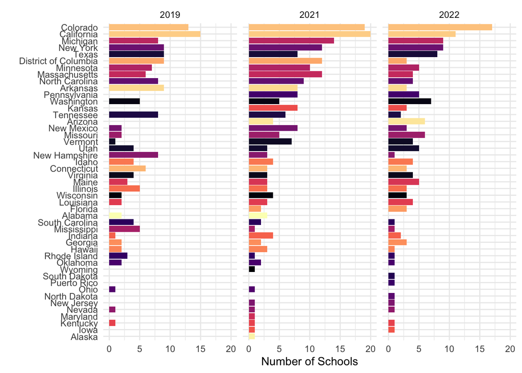

```r
main$school_state[373] <- "South Carolina"
main$school_state[136] <- "California"
main$school_state[377] <- "Washington"
main$school_state[54] <- "New York"

main_count <- main %>%
  filter(school_state != "NA") %>%
  group_by(year) %>%
  dplyr::count(school_state)


main_count %>%
  filter(school_state != "")%>%
  group_by("year")%>%
  ggplot(aes(x = n, y = reorder(school_state, n)))+
  geom_col(aes(fill= school_state), show.legend = FALSE) +
  scale_fill_viridis_d(option = "magma", direction = -1)+
  labs(x = "Number of Schools", y = "")+
  facet_wrap(~year, nrow = 1)+
  theme_minimal()
```

## State Random Model

After examining the data by states, we decided to allow the state data to vary with random intercepts.

```r
GLMMRand1 <- glmer(prac_tot ~ 1 + wave +
                    locale +
                    cbipoc_percent +
                    cfrpl_percent +
                    locale*wave +
                    (1|school_id) +
                     (1|school_state),
                  family = poisson,
                  data = main)
summary(GLMMRand1)
```

```
## Generalized linear mixed model fit by maximum likelihood (Laplace
##   Approximation) [glmerMod]
##  Family: poisson  ( log )
## Formula: prac_tot ~ 1 + wave + locale + cbipoc_percent + cfrpl_percent +
##     locale * wave + (1 | school_id) + (1 | school_state)
##    Data: main
##
##      AIC      BIC   logLik deviance df.resid
##   2042.8   2083.7  -1011.4   2022.8      432
##
## Scaled residuals:
##      Min       1Q   Median       3Q      Max
## -2.33174 -0.68579  0.09317  0.58389  2.40554
##
## Random effects:
##  Groups       Name        Variance Std.Dev.
##  school_id    (Intercept) 0.03111  0.1764
##  school_state (Intercept) 0.01924  0.1387
## Number of obs: 442, groups:  school_id, 321; school_state, 44
##
## Fixed effects:
##                     Estimate Std. Error z value Pr(>|z|)
## (Intercept)          0.99160    0.10368   9.564  < 2e-16 ***
## wave                 0.23097    0.04453   5.187 2.14e-07 ***
## localeSuburban       0.38258    0.13951   2.742 0.006101 **
## localeUrban          0.46091    0.12155   3.792 0.000149 ***
## cbipoc_percent       0.03432    0.03968   0.865 0.387107
## cfrpl_percent        0.05386    0.03277   1.644 0.100241
## wave:localeSuburban -0.09213    0.06164  -1.495 0.135026
## wave:localeUrban    -0.11171    0.05045  -2.214 0.026802 *
## ---
## Signif. codes:  0 '***' 0.001 '**' 0.01 '*' 0.05 '.' 0.1 ' ' 1
##
## Correlation of Fixed Effects:
##             (Intr) wave   lclSbr lclUrb cbpc_p cfrpl_ wv:lcS
## wave        -0.780
## localeSbrbn -0.690  0.582
## localeUrban -0.833  0.647  0.604
## cbipc_prcnt  0.154  0.130 -0.054 -0.281
## cfrpl_prcnt -0.141 -0.058  0.136  0.208 -0.621
## wv:lclSbrbn  0.550 -0.712 -0.812 -0.457 -0.102  0.021
## wav:lclUrbn  0.688 -0.871 -0.520 -0.774 -0.070 -0.003  0.625
## optimizer (Nelder_Mead) convergence code: 0 (OK)
## Model failed to converge with max|grad| = 0.00783685 (tol = 0.002, component 1)
```

```r
tab_model(GLMMRand1)
```

|  | prac tot |  |  |
| --- | --- | --- | --- |
| Predictors | Incidence Rate Ratios | CI | p |
| (Intercept) | 2.70 | 2.20 – 3.30 | **<0.001** |
| wave | 1.26 | 1.15 – 1.37 | **<0.001** |
| locale [Suburban] | 1.47 | 1.12 – 1.93 | **0.006** |
| locale [Urban] | 1.59 | 1.25 – 2.01 | **<0.001** |
| cbipoc percent | 1.03 | 0.96 – 1.12 | 0.387 |
| cfrpl percent | 1.06 | 0.99 – 1.13 | 0.100 |
| wave × locale [Suburban] | 0.91 | 0.81 – 1.03 | 0.135 |
| wave × locale [Urban] | 0.89 | 0.81 – 0.99 | **0.027** |
| Random Effects |  |  |  |
| σ<sup>2</sup> | 0.19 |  |  |
| τ<sub>00</sub> <sub>school_id</sub> | 0.03 |  |  |
| τ<sub>00</sub> <sub>school_state</sub> | 0.02 |  |  |
| ICC | 0.21 |  |  |
| N <sub>school_id</sub> | 321 |  |  |
| N <sub>school_state</sub> | 44 |  |  |
| Observations | 442 |  |  |
| Marginal R<sup>2</sup> / Conditional R<sup>2</sup> | 0.215 / 0.381 |  |  |

```r
AIC(GLMMfix1,GLMMRand1)
```

```
##           df      AIC
## GLMMfix1   9 2046.864
## GLMMRand1 10 2042.811
```

```r
BIC(GLMMfix1,GLMMRand1)
```

```
##           df      BIC
## GLMMfix1   9 2083.686
## GLMMRand1 10 2083.724
```

```r
test_lrt(GLMMfix1,GLMMRand1)
```

```
## # Likelihood-Ratio-Test (LRT) for Model Comparison (ML-estimator)
##
## Name      |    Model | df | df_diff | Chi2 |     p
## --------------------------------------------------
## GLMMfix1  | glmerMod |  9 |         |      |
## GLMMRand1 | glmerMod | 10 |       1 | 6.05 | 0.014
```

Although AIC and BIC are essnetially the same, the Random effects model is considered significantly better using the LRT test.

```r
schools_2018_19 <- import(here("data/schools_2018-19.csv"))
```

Look at school type (Public/private), charter, magnet.

Include “level” - aka high school, elementary, middle, middle/high school

title 1 status - “title_i_status”

```r
GLMMRand2 <- glmer(prac_tot ~ 1 + wave +
                    locale +
                    cbipoc_percent +
                    cfrpl_percent +
                    locale*wave +
                    (1|school_id) +
                     (1|school_state),
                  family = poisson,
                  data = main)
summary(GLMMRand2)
```

```
## Generalized linear mixed model fit by maximum likelihood (Laplace
##   Approximation) [glmerMod]
##  Family: poisson  ( log )
## Formula: prac_tot ~ 1 + wave + locale + cbipoc_percent + cfrpl_percent +
##     locale * wave + (1 | school_id) + (1 | school_state)
##    Data: main
##
##      AIC      BIC   logLik deviance df.resid
##   2042.8   2083.7  -1011.4   2022.8      432
##
## Scaled residuals:
##      Min       1Q   Median       3Q      Max
## -2.33174 -0.68579  0.09317  0.58389  2.40554
##
## Random effects:
##  Groups       Name        Variance Std.Dev.
##  school_id    (Intercept) 0.03111  0.1764
##  school_state (Intercept) 0.01924  0.1387
## Number of obs: 442, groups:  school_id, 321; school_state, 44
##
## Fixed effects:
##                     Estimate Std. Error z value Pr(>|z|)
## (Intercept)          0.99160    0.10368   9.564  < 2e-16 ***
## wave                 0.23097    0.04453   5.187 2.14e-07 ***
## localeSuburban       0.38258    0.13951   2.742 0.006101 **
## localeUrban          0.46091    0.12155   3.792 0.000149 ***
## cbipoc_percent       0.03432    0.03968   0.865 0.387107
## cfrpl_percent        0.05386    0.03277   1.644 0.100241
## wave:localeSuburban -0.09213    0.06164  -1.495 0.135026
## wave:localeUrban    -0.11171    0.05045  -2.214 0.026802 *
## ---
## Signif. codes:  0 '***' 0.001 '**' 0.01 '*' 0.05 '.' 0.1 ' ' 1
##
## Correlation of Fixed Effects:
##             (Intr) wave   lclSbr lclUrb cbpc_p cfrpl_ wv:lcS
## wave        -0.780
## localeSbrbn -0.690  0.582
## localeUrban -0.833  0.647  0.604
## cbipc_prcnt  0.154  0.130 -0.054 -0.281
## cfrpl_prcnt -0.141 -0.058  0.136  0.208 -0.621
## wv:lclSbrbn  0.550 -0.712 -0.812 -0.457 -0.102  0.021
## wav:lclUrbn  0.688 -0.871 -0.520 -0.774 -0.070 -0.003  0.625
## optimizer (Nelder_Mead) convergence code: 0 (OK)
## Model failed to converge with max|grad| = 0.00783685 (tol = 0.002, component 1)
```

```r
tab_model(GLMMRand2)
```

|  | prac tot |  |  |
| --- | --- | --- | --- |
| Predictors | Incidence Rate Ratios | CI | p |
| (Intercept) | 2.70 | 2.20 – 3.30 | **<0.001** |
| wave | 1.26 | 1.15 – 1.37 | **<0.001** |
| locale [Suburban] | 1.47 | 1.12 – 1.93 | **0.006** |
| locale [Urban] | 1.59 | 1.25 – 2.01 | **<0.001** |
| cbipoc percent | 1.03 | 0.96 – 1.12 | 0.387 |
| cfrpl percent | 1.06 | 0.99 – 1.13 | 0.100 |
| wave × locale [Suburban] | 0.91 | 0.81 – 1.03 | 0.135 |
| wave × locale [Urban] | 0.89 | 0.81 – 0.99 | **0.027** |
| Random Effects |  |  |  |
| σ<sup>2</sup> | 0.19 |  |  |
| τ<sub>00</sub> <sub>school_id</sub> | 0.03 |  |  |
| τ<sub>00</sub> <sub>school_state</sub> | 0.02 |  |  |
| ICC | 0.21 |  |  |
| N <sub>school_id</sub> | 321 |  |  |
| N <sub>school_state</sub> | 44 |  |  |
| Observations | 442 |  |  |
| Marginal R<sup>2</sup> / Conditional R<sup>2</sup> | 0.215 / 0.381 |  |  |

# Model Summary

```r
modelsummary::msummary(list(
  "Null Model" = GLMMCond,
  "Model 1" = GLMMfix,
  "Model 2" = GLMMfix1,
  "Model 3" = GLMMRand1),
  stars = TRUE)
```

|  | Null Model | Model 1 | Model 2 | Model 3 |
| --- | --- | --- | --- | --- |
| (Intercept) | 1.318*** | 1.130*** | 0.964*** | 0.992*** |
|  | (0.042) | (0.069) | (0.101) | (0.104) |
| wave | 0.158*** | 0.154*** | 0.247*** | 0.231*** |
|  | (0.018) | (0.020) | (0.044) | (0.045) |
| localeSuburban |  | 0.218** | 0.401** | 0.383** |
|  |  | (0.082) | (0.140) | (0.140) |
| localeUrban |  | 0.262*** | 0.484*** | 0.461*** |
|  |  | (0.076) | (0.120) | (0.122) |
| cbipoc_percent |  | 0.031 | 0.037 | 0.034 |
|  |  | (0.038) | (0.038) | (0.040) |
| cfrpl_percent |  | 0.048 | 0.050 | 0.054 |
|  |  | (0.032) | (0.032) | (0.033) |
| wave × localeSuburban |  |  | −0.099 | −0.092 |
|  |  |  | (0.062) | (0.062) |
| wave × localeUrban |  |  | −0.122* | −0.112* |
|  |  |  | (0.050) | (0.050) |
| SD (Intercept school_id) | 0.276 | 0.222 | 0.215 | 0.176 |
| SD (Intercept school_state) |  |  |  | 0.139 |
| Num.Obs. | 566 | 442 | 442 | 442 |
| R2 Marg. | 0.118 | 0.206 | 0.235 | 0.215 |
| R2 Cond. | 0.375 | 0.374 | 0.388 | 0.381 |
| AIC | 2628.3 | 2048.8 | 2046.9 | 2042.8 |
| BIC | 2641.3 | 2077.4 | 2083.7 | 2083.7 |
| ICC | 0.3 | 0.2 | 0.2 | 0.2 |
| RMSE | 1.69 | 1.84 | 1.85 | 1.86 |

+ p < 0.1, * p < 0.05, ** p < 0.01, *** p < 0.001